# joins_solved

## How connected are airports?

We could rank the "connectiveness" of an airport and their associated cities by its reach around the globe. Specifically, how many cities are within 1 direct flight or within 1 transfer flight of each city.

We will perform some basic JOIN operations for this to compare the 2019 vs 2020 data.

### Porblem 0 data exploration

- Please verify the claim that "at least one of the origin or destination airports must be from the US".
- How many foreign countries have a direct flight with the US in 2019 (either way)?
- What unit is the distance in?
- (No code) To calculate all possible airports within 2 flights from JFK, what information is the data missing?
- Are there countries that do not have "round trip" relationships with the US if you are restricted to only direct flights?
- Is there a one to one relationship between `ORIGIN_AIRPORT_ID` and `ORIGIN`?
  - (optional) If you find something weird, what would you say is causing it?
- How many unique airports are out there in the US?

```r
#df <- read.csv("~/Downloads/T_100_MARKET_DOM_INT_2019.csv", stringsAsFactors=FALSE)
df <- read.csv("~/Downloads/airports.csv", stringsAsFactors=FALSE)
```

```r
head(df)
```

A data.frame: 6 × 6

|  | ORIGIN_AIRPORT_ID <int> | ORIGIN <chr> | ORIGIN_COUNTRY <chr> | DEST_AIRPORT_ID <int> | DEST <chr> | DEST_COUNTRY <chr> |
| --- | --- | --- | --- | --- | --- | --- |
| 1 | 13264 | MFR | US | 13264 | MFR | US |
| 2 | 13785 | NYL | US | 13785 | NYL | US |
| 3 | 14057 | PDX | US | 14057 | PDX | US |
| 4 | 15370 | TUL | US | 15370 | TUL | US |
| 5 | 14843 | SJU | US | 14843 | SJU | US |
| 6 | 13303 | MIA | US | 13303 | MIA | US |

```r
library(dplyr)
```

```r
tail(df)
```

A data.frame: 6 × 6

|  | ORIGIN_AIRPORT_ID <int> | ORIGIN <chr> | ORIGIN_COUNTRY <chr> | DEST_AIRPORT_ID <int> | DEST <chr> | DEST_COUNTRY <chr> |
| --- | --- | --- | --- | --- | --- | --- |
| 321151 | 13243 | MEL | AU | 12478 | JFK | US |
| 321152 | 13243 | MEL | AU | 12478 | JFK | US |
| 321153 | 11298 | DFW | US | 14071 | PER | AU |
| 321154 | 12520 | JNB | ZA | 13796 | OAK | US |
| 321155 | 14071 | PER | AU | 12266 | IAH | US |
| 321156 | 12266 | IAH | US | 14071 | PER | AU |

```r
# Verification checks out
all(df$ORIGIN_COUNTRY == "US" | df$DEST_COUNTRY == "US")
```

TRUE

```r
out <- df %>% filter(ORIGIN_COUNTRY != "US" | DEST_COUNTRY != "US") %>%
    transmute(foreign_country=ifelse(ORIGIN_COUNTRY == 'US', DEST_COUNTRY, ORIGIN_COUNTRY)) %>%
    group_by(foreign_country) %>%
    summarize(n())
```

```r
# 149 foreign countries
nrow(out)
```

149

```r
# The distance are in miles, this can be found on the website
```

```r
# We are missing the foreign airport to foreign airport information
```

```r
head(out, 3)
```

A tibble: 3 × 2

| foreign_country <chr> | n() <int> |
| --- | --- |
| AE | 575 |
| AF | 6 |
| AG | 241 |

```r
dest_countries <- df %>% filter(ORIGIN_COUNTRY == "US", DEST_COUNTRY != "US") %>%
    select(DEST_COUNTRY) %>% unique()
```

```r
# Not all countries are on the destination list
mean(out$foreign_country %in% dest_countries$DEST_COUNTRY)
```

0.946308724832215

```r
head(out$foreign_country[!out$foreign_country %in% dest_countries$DEST_COUNTRY])
```

1. 'BG'

2. 'GA'

3. 'GL'

4. 'GQ'

5. 'ML'

6. 'MO'

```r
# There is a differnce so the relationship isn't one to one
length(unique(df$ORIGIN_AIRPORT_ID)) - length(unique(df$ORIGIN))
```

1

```r
# Optional
aid_count <- df %>% select(ORIGIN_AIRPORT_ID, ORIGIN) %>%
    unique() %>% group_by(ORIGIN) %>% summarize(n=n())
aid_count[aid_count$n > 1,]
```

A tibble: 2 × 2

| ORIGIN <chr> | n <int> |
| --- | --- |
| IST | 2 |
| XWA | 2 |

```r
# Optional
aid_count <- df %>% select(ORIGIN_AIRPORT_ID, ORIGIN) %>%
    unique() %>% group_by(ORIGIN_AIRPORT_ID) %>% summarize(n=n())
aid_count[aid_count$n > 1,]
```

A tibble: 1 × 2

| ORIGIN_AIRPORT_ID <int> | n <int> |
| --- | --- |
| 12395 | 2 |

### Problem 1

- Please remove the `*_AIRPORT_ID` variables from the data frame.
  - Do we need to deduplicate the data after removing the airport ID? Why or why not?
- At least how many airports within the US are reachable from JFK using 2 or fewer flights?
  - What about ATL? Please wrap your code from above into a function!
  - Which airport is more connected?
- How many airports are in the US?
- Sample the US airports and plot the relationship between the number of airports reachable by a direct flight vs by 2 flights (each dot is an airport). What relationship do you expect to see? (Plot it afterwards to verify!)

```r
df <- df %>% select(-ends_with("AIRPORT_ID")) %>% unique()
```

```r
head(df)
```

A data.frame: 6 × 4

|  | ORIGIN <chr> | ORIGIN_COUNTRY <chr> | DEST <chr> | DEST_COUNTRY <chr> |
| --- | --- | --- | --- | --- |
| 1 | MFR | US | MFR | US |
| 2 | NYL | US | NYL | US |
| 3 | PDX | US | PDX | US |
| 4 | TUL | US | TUL | US |
| 5 | SJU | US | SJU | US |
| 6 | MIA | US | MIA | US |

```r
connected <- function(origin, df) {
    thin_df <- df %>% select(ORIGIN, DEST, DEST_COUNTRY)
    flight1 <- thin_df %>% filter(ORIGIN == origin)
    thin_df2 <- thin_df %>% filter(DEST_COUNTRY == "US")
    names(thin_df2) <- paste0(names(thin_df), ".y")
    flight2 <- merge(flight1, thin_df2, by.x = "DEST",
                     by.y= "ORIGIN.y", all.x = TRUE)
    # filter below cannot be done earlier otherwise the
    # join would miss flights that leave the country and
    # fly back in
    flight1 <- filter(flight1, DEST_COUNTRY == "US")
    return(list(f1=unique(flight1$DEST),
                f2=unique(flight2$DEST.y)))
}
```

```r
out <- connected("JFK", df)
```

```r
length(out[[1]])
```

126

```r
length(out[[2]])
```

981

```r
dep_us_airports <- unique(df$ORIGIN[df$ORIGIN_COUNTRY=="US"])
```

```r
arr_us_airports <- unique(df$DEST[df$DEST_COUNTRY=="US"])
```

```r
arr_us_airports[!(arr_us_airports %in% dep_us_airports)]
```

1. 'FNR'

2. 'KKU'

3. 'A50'

4. 'RLD'

5. 'BYW'

6. 'TTD'

7. 'GMT'

8. 'PA4'

9. 'ATS'

10. 'ZXC'

11. 'N2Y'

12. 'JLA'

13. '6B0'

14. 'P1A'

15. 'XXU'

16. 'GTY'

17. 'JZM'

18. 'EFK'

19. 'BML'

20. 'SDX'

21. 'OSH'

22. 'NY3'

23. 'GMU'

24. 'MAE'

25. 'RRT'

26. 'XXW'

27. 'MUL'

28. 'VCB'

29. 'AIO'

30. 'DQP'

31. 'MSC'

32. 'FL7'

33. 'DNE'

34. 'FCM'

35. 'RCA'

36. 'RKH'

37. 'LEE'

38. 'OLM'

39. 'AL7'

40. 'UXP'

41. 'TIX'

```r
all_us_airports <- unique(c(dep_us_airports, arr_us_airports))
length(all_us_airports)
```

1326

```r
# There are more unique airports than airports that can be reached in 2 flights.
# So not all airports are reachable within 2 flights.
```

```r
out <- connected("ATL", df)
```

```r
length(out[[1]])
length(out[[2]])
```

213

1033

```r
conn_mat <- matrix(0, ncol=2, nrow=length(all_us_airports))
for(i in seq_along(all_us_airports)){
    if(i %% 100 == 0) print(paste("iteration", i))
    out <- connected(all_us_airports[i], df)
    conn_mat[i, ] <- c(length(out[[1]]), length(out[[2]]))
}
rownames(conn_mat) <- all_us_airports
```

```
[1] "iteration 100"
[1] "iteration 200"
[1] "iteration 300"
[1] "iteration 400"
[1] "iteration 500"
[1] "iteration 600"
[1] "iteration 700"
[1] "iteration 800"
[1] "iteration 900"
[1] "iteration 1000"
[1] "iteration 1100"
[1] "iteration 1200"
[1] "iteration 1300"
```

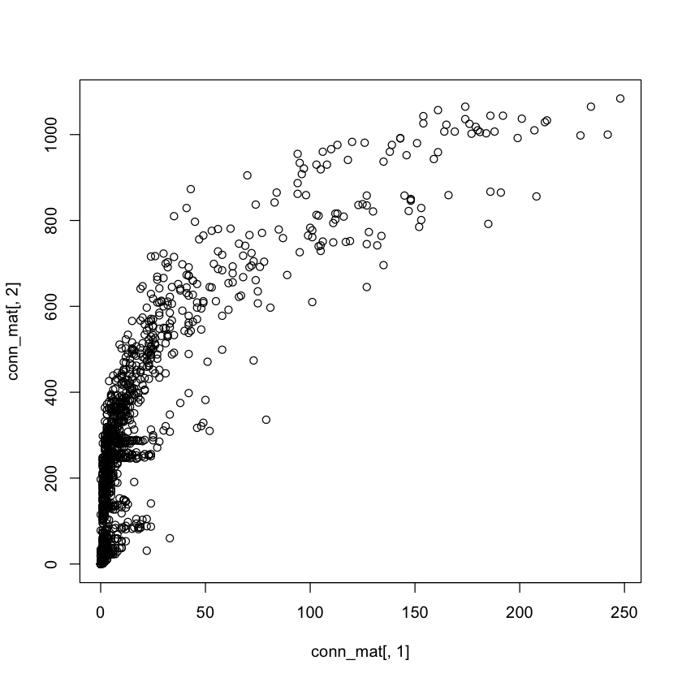

```r
plot(conn_mat[, 1], conn_mat[, 2])
```

```r
which.max(conn_mat[, 1])
```

**ORD:** 70

### Problem 2 Impact of locking down?

- The Lombardy region in Italy was the hardest hit by COVID-19 and one of its airports is MXP.
- The Wuhan region in China is the origin of the COVID-19 pandemic and one of its airports is WUH.

(Wayne does not know if there are other airports in either region)

How would US domestic travel be impacted if we shutdown the airports with traffic **from** these two airports? This problem is intentionally open-ended. How would you quantify/visualize this?

- Domestic travel means that your flight never leaves the US territory
- Who is your audience and would your report change?

```r
from_wuh <- df[df$ORIGIN == "WUH", "DEST"]
```

```r
from_mxp <- df[df$ORIGIN == "MXP", "DEST"]
```

```r
from_hotspot <- unique(c(from_wuh, from_mxp))
```

```r
length(from_hotspot)
```

16

```r
us_dom <- df %>% filter(ORIGIN_COUNTRY == "US",
                        DEST_COUNTRY == "US") %>%
                 select(ORIGIN, DEST) %>% unique()
```

```r
dim(us_dom)
```

1. 26994

2. 2

```r
head(us_dom)
```

A data.frame: 6 × 2

|  | ORIGIN <chr> | DEST <chr> |
| --- | --- | --- |
| 1 | MFR | MFR |
| 2 | NYL | NYL |
| 3 | PDX | PDX |
| 4 | TUL | TUL |
| 5 | SJU | SJU |
| 6 | MIA | MIA |

```r
us_dom_lock <- us_dom %>% filter(!(ORIGIN %in% from_hotspot | DEST %in% from_hotspot))
```

```r
dim(us_dom_lock)
```

1. 21917

2. 2

```r
(21917 - 26994) / 26994
```

-0.188078832333111

**Bare minimum**, they should note that shutting down 16 airports causes a drop in near one out of every five ($\approx$ 5000 drop out of 27000) flight paths being shutdown in the US. Students should avoid using -19% from a communication standpoint.

Pro/Con:

- This is a powerful quick & dirty statistic but **does not have a good visual** to go with it.
- The audience for this is mostly the government since it's a global description of the problem. For local airport agencies, this is hard to understand because at most 16 of their flights are cancelled only.

```r
dom_connected <- function(origin, us_dom){
    flight1 <- us_dom %>% filter(ORIGIN == origin)
    dom2 <- us_dom
    names(dom2) <- paste0(names(us_dom), ".y")
    flight2 <- merge(flight1, dom2, by.x = "DEST",
                     by.y= "ORIGIN.y", all.x = TRUE)
    return(list(f1=unique(flight1$DEST), f2=unique(flight2$DEST.y)))
}
```

```r
sum(!all_us_airports %in% from_hotspot)
```

1310

```r
unlocked_us_airports <- all_us_airports[!all_us_airports %in% from_hotspot]
```

```r
pre_lock_mat <- matrix(0, ncol=2, nrow=length(unlocked_us_airports))
post_lock_mat <- pre_lock_mat
for(i in seq_along(unlocked_us_airports)){
    if(i %% 100 == 0) print(paste("iteration", i))
    out_pre <- dom_connected(unlocked_us_airports[i], us_dom)
    out_post <- dom_connected(unlocked_us_airports[i], us_dom_lock)
    pre_lock_mat[i, ] <- c(length(out_pre[[1]]), length(out_pre[[2]]))
    post_lock_mat[i, ] <- c(length(out_post[[1]]), length(out_post[[2]]))
}
```

```
[1] "iteration 100"
[1] "iteration 200"
[1] "iteration 300"
[1] "iteration 400"
[1] "iteration 500"
[1] "iteration 600"
[1] "iteration 700"
[1] "iteration 800"
[1] "iteration 900"
[1] "iteration 1000"
[1] "iteration 1100"
[1] "iteration 1200"
[1] "iteration 1300"
```

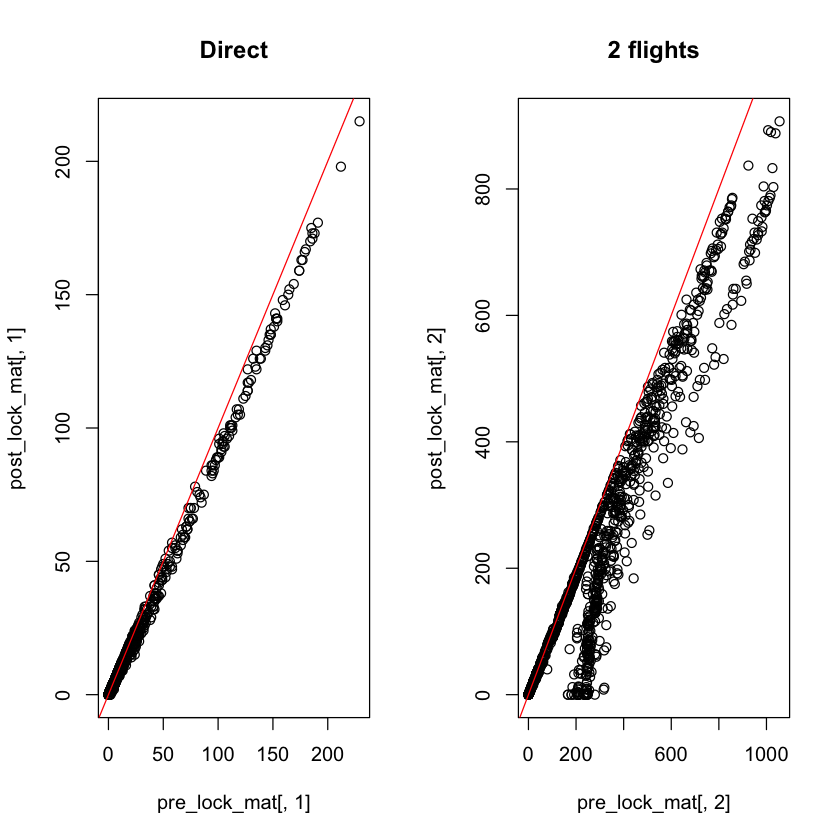

```r
par(mfrow=c(1, 2))
plot(pre_lock_mat[, 1], post_lock_mat[, 1], main="Direct")
abline(a=0, b=1, col="red")
plot(pre_lock_mat[, 2], post_lock_mat[, 2], main="2 flights")
abline(a=0, b=1, col="red")
```

- The damage is much more pronounced in the 2 flight scenario for any airport, i.e. although their immediate connection is capped at 16, their network within 2 flights is drastically cutdown.